# R Notebook

### Atribúty pim.home a pim.away

**charakteristika:** atribút hovorí o počte trestných minút pre jednotlivé tímy. Keďže sú najčastejšie vylúčenia sankciované dvoma minútami, tak sa budú párne hodnoty vyskytovať častejšie. No poznáme aj dlhšie tresty ako 2+2, 5, 5+2, alebo aj netradičné tresty. Vylúčenia do konca zápasu za nešportové správanie sa do tejto štatistiky nezarátavajú - jedná sa teda o reálnu minutáž, ktorú strávi hráč na trestnej lavici a jeho tím je tým pádom oslabený (osobné tresty neoslabujú tím počas celej dĺžky trestu).

```r
summary(df$pim.home)
```

```
   Min. 1st Qu.  Median    Mean 3rd Qu.    Max.    NA's
  0.000   4.000   8.000   8.606  10.000  78.000       4
```

```r
summary(df$pim.away)
```

```
   Min. 1st Qu.  Median    Mean 3rd Qu.    Max.    NA's
  0.000   6.000   8.000   9.287  11.000  96.000       4
```

Zo zhodnotenia vidíme, že hodnoty sú priateľné a dávajú logicky zmysel, ale maximálne hodnoty sú veľmi vychýlené a záznamy majú chýbajúcu hodnotu pre tento atribút. Tatkiež sa vyskytujú už známe chýbajúce 4 hodnoty (NA).

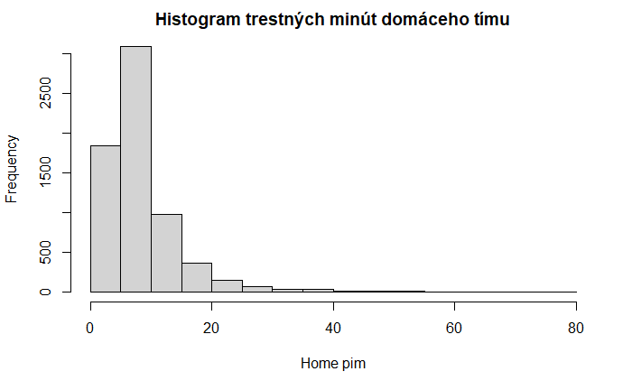

```r
hist(df$pim.home, xlab="Home pim", main="Histogram trestných minút domáceho tímu")
```

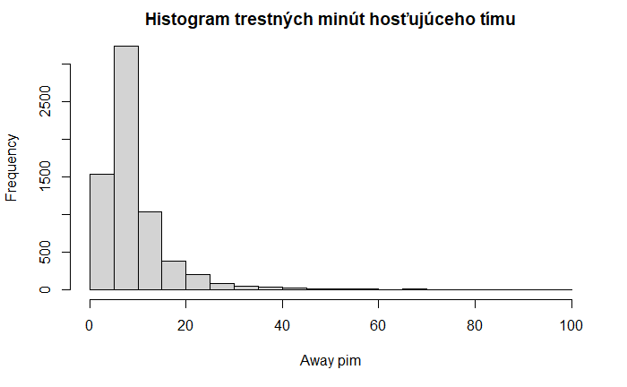

```r
hist(df$pim.away,  xlab="Away pim", main="Histogram trestných minút hosťujúceho tímu")
```

Podľa grafu neobsahuje atribút normálne rozdelenie. Hodnoty skôr pripomínajú long-tail rozdelenie.

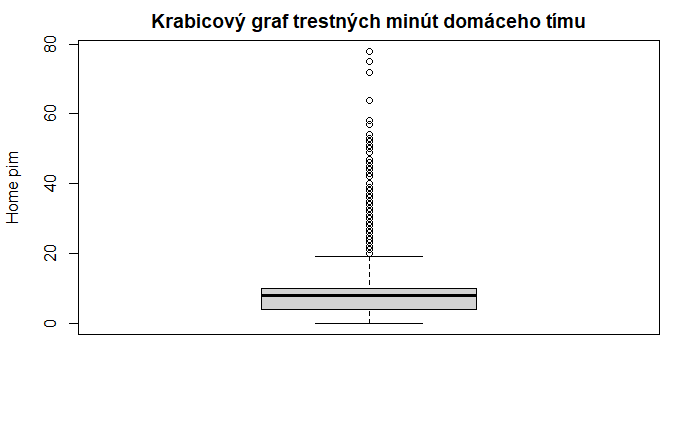

```r
boxplot(df$pim.home, ylab="Home pim", main="Krabicový graf trestných minút domáceho tímu")
```

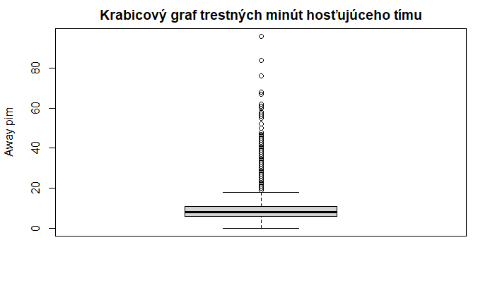

```r
boxplot(df$pim.away, ylab="Away pim", main="Krabicový graf trestných minút hosťujúceho tímu")
```

Krabicový graf nám iba potvrdil, že atribút obsahuje viacero vychýlených hodnôt, na ktoré sa budeme musieť pozrieť a navrhnúť možnú úpravu. Predbežne odporúčame normalizáciu atribútov pokiaľ sú väčšie rovné ako 60, no túto skutočnosť ešte overíme neskôr na grafe rozptylu.

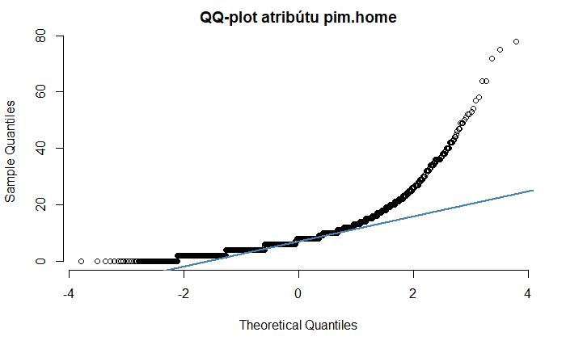

```r
qqnorm(df$pim.home, pch = 1, frame = FALSE, main="QQ-plot atribútu pim.home")
qqline(df$pim.home, col = "steelblue", lwd = 2)
```

```
[1] 3872  136
```

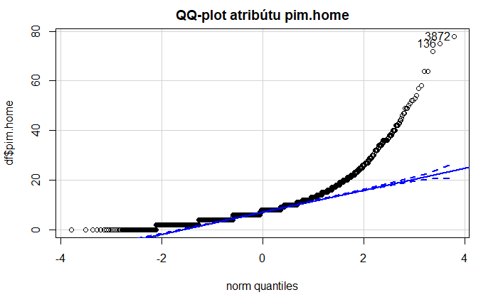

```r
qqPlot(df$pim.home, main="QQ-plot atribútu pim.home")
```

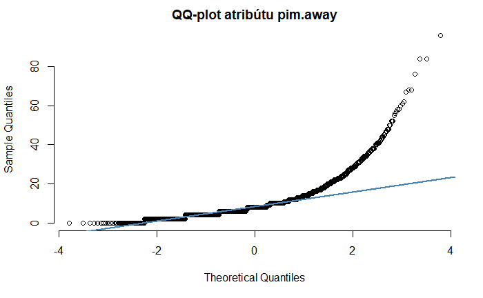

```r
qqnorm(df$pim.away, pch = 1, frame = FALSE, main="QQ-plot atribútu pim.away")
qqline(df$pim.away, col = "steelblue", lwd = 2)
```

```
[1]  136 1157
```

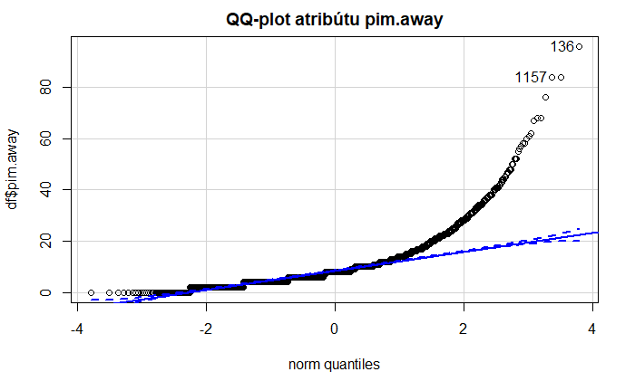

```r
qqPlot(df$pim.away, main="QQ-plot atribútu pim.away")
```

Q-Q grafy nám dokázali, že sa nejedná o normálne rozdelenie a hodnoty sa mu ani nepribližujú. Test normality teda nebude potrebný.

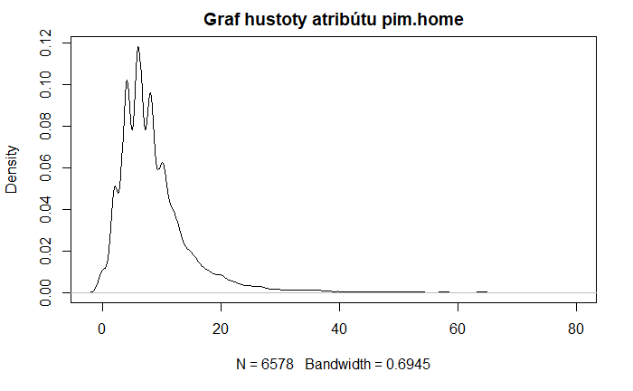

```r
plot(density(na.omit(df$pim.home)), main="Graf hustoty atribútu pim.home")
```

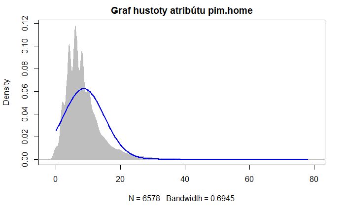

```r
plotNormalDensity(df$pim.home, main="Graf hustoty atribútu pim.home")
```

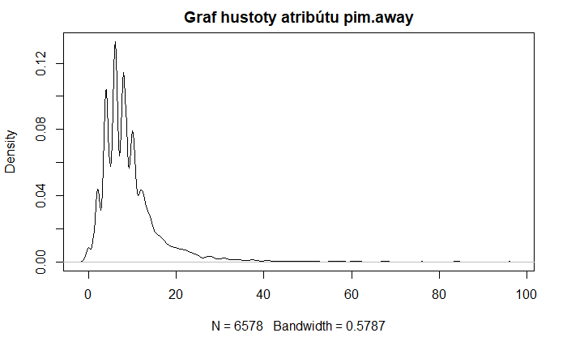

```r
plot(density(na.omit(df$pim.away)), main="Graf hustoty atribútu pim.away")
```

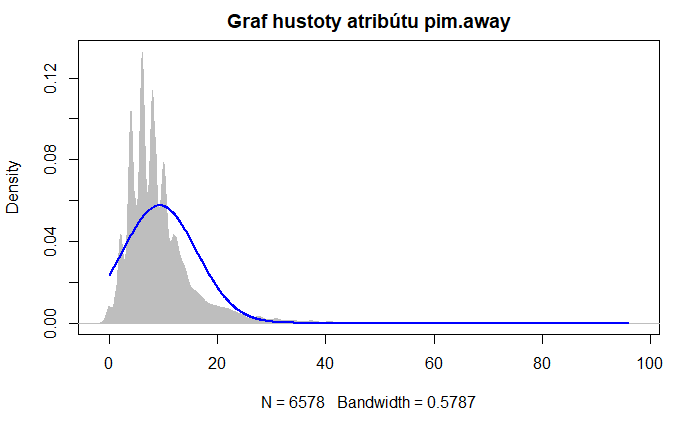

```r
plotNormalDensity(df$pim.away, main="Graf hustoty atribútu pim.away")
```

Atribúty majú veľmi nezvyčajú hustotu rozdelenia hodnôt, čo je zapríčinené hlavne z dvôdou dvojminutových trestov. Hustota nepripomína normálne rozdelenie v podstate na žiadnom intervale, čize o normálne rozdelenie sa na základe grafov konať určite nebude.

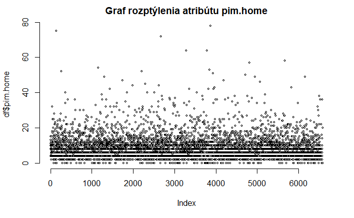

```r
plot(df$pim.home, pch = 21, bg = "lightgray", col = "black", cex = 0.5, frame = FALSE, main="Graf rozptýlenia atribútu pim.home")
```

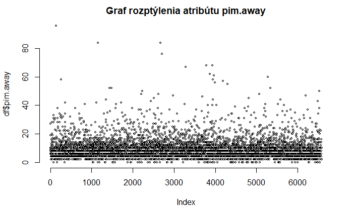

```r
plot(df$pim.away, pch = 21, bg = "lightgray", col = "black", cex = 0.5, frame = FALSE, main="Graf rozptýlenia atribútu pim.away")
```

Graf rozptylu dokazuje teóriu, že počty trestných minút sú naozaj riedke pri hodnotách väčších ako 40. 40 minút však ešte možno považovať na “normálne” hodnoty, no 60+ sú už naozaj extrémne. Z riedkosti grafu pre oba atribúty pri y>= 60 vieme povedať, že hodnoty sú extrémne a môžeme ich znormalizovať napr. nahradením za horný kvantil (75%).